# LogisticRegression

Chase Enzweiler

10/23/2017

```r
# credit default data
library(ISLR)
library(FactoMineR)
```

```r
library(ggplot2)
```

Run logistic regression

```r
# logistic regression

n <- dim(Default)[1]

p <- dim(Default)[2]


# logistic regression
log_reg_default <- glm(default ~ balance, family = binomial, data = Default)

summary(log_reg_default)$coefficients
```

```
##                  Estimate   Std. Error   z value      Pr(>|z|)
## (Intercept) -10.651330614 0.3611573721 -29.49221 3.623124e-191
## balance       0.005498917 0.0002203702  24.95309 1.976602e-137
```

use predict() to obtain the probability of default for individuals with balance of 100, 200, …, 2000

```r
# predictions

# new data the balances
new_data <- data.frame(seq(100, 2000, 100))
colnames(new_data) <- c("balance")

predict(log_reg_default, newdata = new_data, type = "response" )
```

```
##            1            2            3            4            5
## 4.101880e-05 7.108613e-05 1.231905e-04 2.134779e-04 3.699132e-04
##            6            7            8            9           10
## 6.409100e-04 1.110217e-03 1.922514e-03 3.327154e-03 5.752145e-03
##           11           12           13           14           15
## 9.926984e-03 1.707982e-02 2.923441e-02 4.960213e-02 8.294762e-02
##           16           17           18           19           20
## 1.355136e-01 2.136317e-01 3.201070e-01 4.493274e-01 5.857694e-01
```

Now fit a logistic regression model by regressing default on student. Intepret the coefficient estimate

```r
# default of student

log_reg_stu <- glm(default ~ student, family = binomial, data = Default)

summary(log_reg_stu)$coefficients
```

```
##               Estimate Std. Error    z value     Pr(>|z|)
## (Intercept) -3.5041278 0.07071301 -49.554219 0.0000000000
## studentYes   0.4048871 0.11501883   3.520181 0.0004312529
```

our coefficient estimate for studentYes is positive and therefore the students have a better chance at defaulting than non-students Now regress default on student, balance, and income.

```r
# logistic regression on student balance and income

log_reg_bsi <- glm(default ~ balance + student + income, family = binomial, data = Default)

summary(log_reg_bsi)$coefficients
```

```
##                  Estimate   Std. Error    z value      Pr(>|z|)
## (Intercept) -1.086905e+01 4.922555e-01 -22.080088 4.911280e-108
## balance      5.736505e-03 2.318945e-04  24.737563 4.219578e-135
## studentYes  -6.467758e-01 2.362525e-01  -2.737646  6.188063e-03
## income       3.033450e-06 8.202615e-06   0.369815  7.115203e-01
```

### Stock Market data

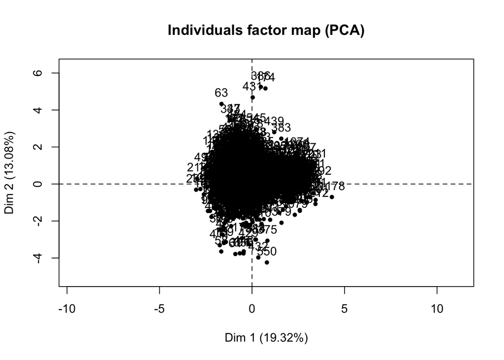

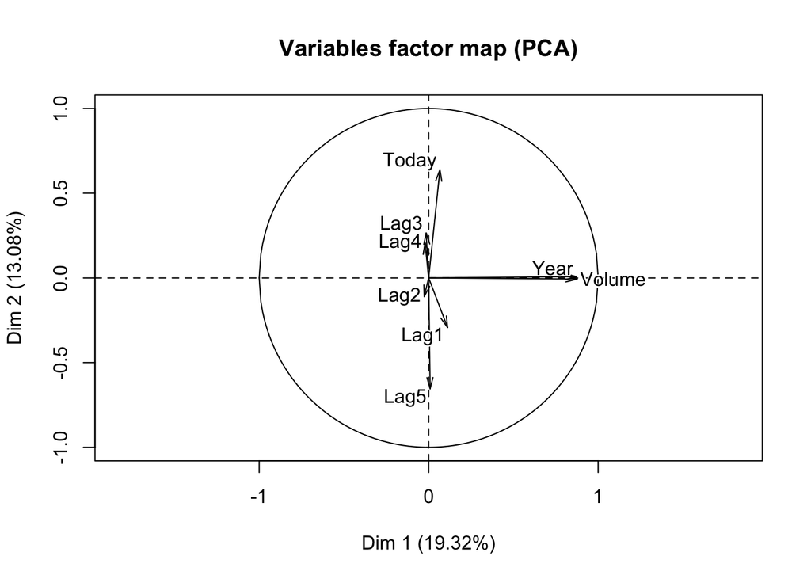

```
## **Results for the Principal Component Analysis (PCA)**
## The analysis was performed on 1250 individuals, described by 8 variables
## *The results are available in the following objects:
##
##    name               description
## 1  "$eig"             "eigenvalues"
## 2  "$var"             "results for the variables"
## 3  "$var$coord"       "coord. for the variables"
## 4  "$var$cor"         "correlations variables - dimensions"
## 5  "$var$cos2"        "cos2 for the variables"
## 6  "$var$contrib"     "contributions of the variables"
## 7  "$ind"             "results for the individuals"
## 8  "$ind$coord"       "coord. for the individuals"
## 9  "$ind$cos2"        "cos2 for the individuals"
## 10 "$ind$contrib"     "contributions of the individuals"
## 11 "$call"            "summary statistics"
## 12 "$call$centre"     "mean of the variables"
## 13 "$call$ecart.type" "standard error of the variables"
## 14 "$call$row.w"      "weights for the individuals"
## 15 "$call$col.w"      "weights for the variables"
```

```r
# PCA on stockmarket data
cor_mat <- cor(Smarket[,-9])

PCA(Smarket[,-9])
```

the lag variables are not very well correlated with the today variable and they have correlations close to zero. The previous days returns are not well correlated with todays returns.

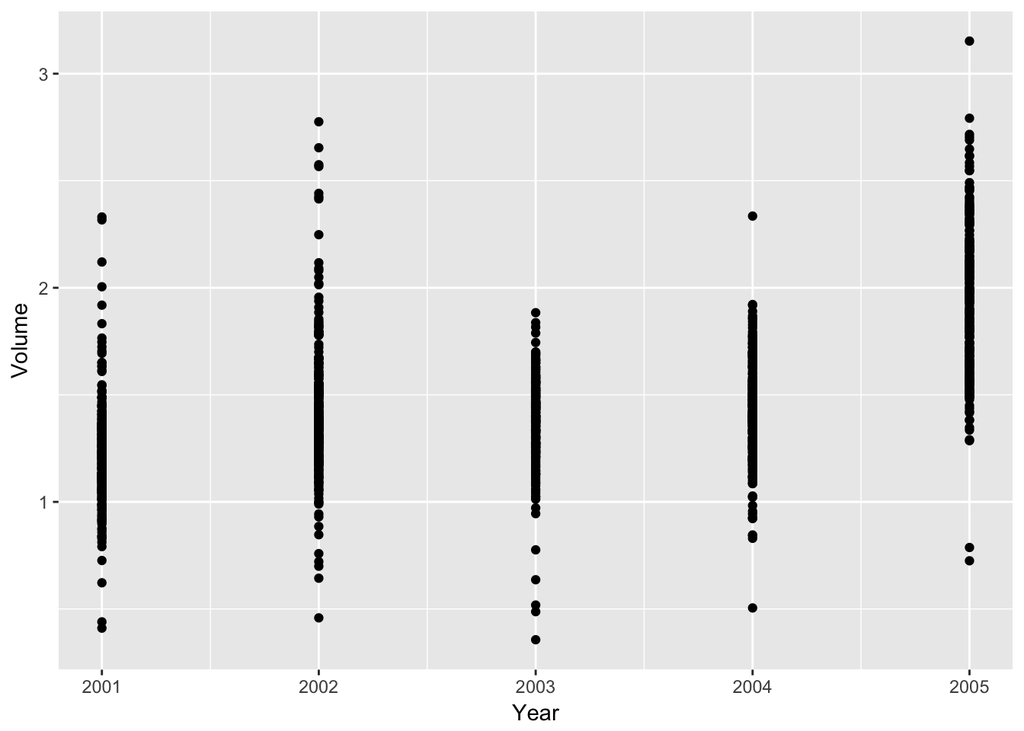

```r
# make a scatter plot of the year and the volume
ggplot(data = Smarket, aes(Year, Volume)) + geom_point()
```

### Logistic Regression

```r
# logistic regression direction on lags and volume

market_log_reg <- glm(Direction ~ Lag1 + Lag2 + Lag3 + Lag4 + Lag5 + Volume, family = binomial, data = Smarket)

summary(market_log_reg)
```

```
##
## Call:
## glm(formula = Direction ~ Lag1 + Lag2 + Lag3 + Lag4 + Lag5 +
##     Volume, family = binomial, data = Smarket)
##
## Deviance Residuals:
##    Min      1Q  Median      3Q     Max
## -1.446  -1.203   1.065   1.145   1.326
##
## Coefficients:
##              Estimate Std. Error z value Pr(>|z|)
## (Intercept) -0.126000   0.240736  -0.523    0.601
## Lag1        -0.073074   0.050167  -1.457    0.145
## Lag2        -0.042301   0.050086  -0.845    0.398
## Lag3         0.011085   0.049939   0.222    0.824
## Lag4         0.009359   0.049974   0.187    0.851
## Lag5         0.010313   0.049511   0.208    0.835
## Volume       0.135441   0.158360   0.855    0.392
##
## (Dispersion parameter for binomial family taken to be 1)
##
##     Null deviance: 1731.2  on 1249  degrees of freedom
## Residual deviance: 1727.6  on 1243  degrees of freedom
## AIC: 1741.6
##
## Number of Fisher Scoring iterations: 3
```

Looking at the p values of the coefficients we can see that none of the coefficients are statistically significant. The coefficient of Lag1 is -0.073074, we interpret this as the market is more likely to go down when Lag1 gets good returns???

```r
# predict
predict(market_log_reg, newdata = Smarket, type = "response")[1:10]
```

```
##         1         2         3         4         5         6         7
## 0.5070841 0.4814679 0.4811388 0.5152224 0.5107812 0.5069565 0.4926509
##         8         9        10
## 0.5092292 0.5176135 0.4888378
```

### Estimation of Parameters

```r
# Newton Raphson Method
library(MASS)
Newt_Raph <- function(formula, response , data){

  # get column vector of the response
  y <- response

  # create design matrix (n x p+1)
  X <- model.matrix(formula, data = data)

  n <- dim(X)[1]

  p <- dim(X)[2]

  # old coefficient estimates vector originally set to zero
  B_old <- rep(1, p)

  # create variable of vector of new coefficients
  B_new <- rep(0, p)


  # iterate until B_old and B_new are "close"
  while (!identical(round(B_old, digits = 2), round(B_new, digits = 2))){

    # set B_old to B_new

    B_old <- B_new

    # compute p, the n vector of fitted probabilites with ith element
    # of p(xi, B_old), transposes in equation dont translate

    # fitted probabilities vector length n
    P <- c()

    # elements of diagonal of W, vector length n
    W_elem <- c()

    for (i in 1 : n){

      P[i] <- exp( X[i,] %*% B_old ) / ( 1 + exp( X[i,] %*% B_old ))

      # compute the i elements for the diagonal of matrix W

      W_elem[i] <- P[i] * (1 - P[i])

    }

    # calculate z

    z <- (X %*% B_old) + solve(diag(W_elem)) %*% (y - P)

    # calculate our new estimated coefficients
    B_new <- solve(t(X) %*% diag(W_elem) %*% X) %*% t(X) %*% diag(W_elem) %*% z

  }

  return(list("coefficients" = B_new))

}

market <- Smarket

# convert UP/Down to 1's and 0's
market$Direction <- as.numeric(Smarket$Direction)-1

Newt_Raph(Direction ~ Lag1 + Lag2 + Lag3 + Lag4 + Lag5 + Volume, response = market$Direction, data = market)
```

```
## $coefficients
##                     [,1]
## (Intercept) -0.126000259
## Lag1        -0.073073747
## Lag2        -0.042301345
## Lag3         0.011085108
## Lag4         0.009358938
## Lag5         0.010313069
## Volume       0.135440661
```

Simple Newton Raphson

```r
# simple newton raphson
Simple_Newt_Raph <- function(formula, response , data){

  # get column vector of the response
  y <- response

  # create design matrix (n x p+1)
  X <- model.matrix(formula, data = data)

  n <- dim(X)[1]

  p <- dim(X)[2]

  # old coefficient estimates vector originally set to zero
  B_old <- rep(1, p )

  # create variable of vector of new coefficients
  B_new <- rep(0, p )

  X_tilda <- matrix(0, ncol = p, nrow = n)

  # iterate until B_old and B_new are "close"
  while (!identical(round(B_old, digits = 2), round(B_new, digits = 2))){

    # set B_old to B_new

    B_old <- B_new

    # compute p, the n vector of fitted probabilites with ith element
    # of p(xi, B_old), transposes in equation dont translate

    # fitted probabilities vector length n
    P <- c()

    # elements of diagonal of W, vector length n
    W_elem <- c()

    for (i in 1 : n){

      P[i] <- exp( X[i,] %*% B_old ) / ( 1 + exp( X[i,] %*% B_old ))

      # compute the i elements for the diagonal of matrix W

      W_elem[i] <- P[i] * (1 - P[i])

      X_tilda[i, ] <- X[i, ] * W_elem[i]

    }




    # calculate our new estimated coefficients
    B_new <- B_old + solve(t(X) %*% X_tilda) %*% t(X) %*% (y - P)

   }

  return(list("coefficients" = B_new))

}

# says t(X) %*% X is computationally singular

Simple_Newt_Raph(Direction ~ Lag1 + Lag2 + Lag3 + Lag4 + Lag5 + Volume, response = market$Direction, data = market)
```

```
## $coefficients
##              [,1]
## [1,] -0.126000259
## [2,] -0.073073747
## [3,] -0.042301345
## [4,]  0.011085108
## [5,]  0.009358938
## [6,]  0.010313069
## [7,]  0.135440661
```